# Certified Stetcu–Baroni Ground-State Filtering from DMRG Trial States: Rigorous Bounds, a Hybrid Empirical Protocol, and a Resource Comparison for the J1–J2 Chain

Draft prepared from the `AARON/j1j2_filter` code base (internal evaluation; authors to be added)

6 October 2026

## Abstract

Ground states of one-dimensional spin chains are routinely obtained classically by DMRG; a hybrid quantum workflow compiles the DMRG matrix-product state (MPS) into a shallow circuit and repairs its residual error with the ancilla-based projection algorithm of Stetcu, Baroni and Carlson. We study this workflow for the open spin-½ $J_1$–$J_2$ chain with a classically optimised, *certified* product-of-cosines filter and first-order Lie–Trotter evolution, and ask three questions: is the error analysis correct, how conservative is it, and does the filter beat simply preparing the MPS better? **(1) Correctness.** We re-derive the analysis and test every building block against brute force (pulse convention, spectral-suppression certificates, leakage bound, commutator constant, composed bound); no violation occurred in any test, and we prove a sharpened angle-based composition that tightens the bound by 2.5–3.1× and the a-priori step count by 2.3–3.2×. **(2) Conservatism.** The rigorous step count is 17–1200× the oracle-empirical one. We trace this to the worst-case commutator constant: the ground state feels a first-order Trotter coefficient 28–41× below it at $J_2=0$ (9–13× at $J_2=0.4$), a gap that *widens* with $N$, plus 4× pulse-level and 2× composition slack. We propose a **hybrid protocol** — rigorous leakage certificate plus a Richardson-type empirical Trotter estimate that does not use the exact ground state — which met its infidelity target in every completed case ($N=6$–$12$) at roughly 30–1300× lower CX cost than the certified circuits. **(3) Resource comparison.** Against the `mps-to-circuit` approximate and sequential (exact) MPS circuits and generic state preparation, the best baseline is cheaper than the certified filter by $10^{2}$–$10^{5}\times$ and than the hybrid protocol by 5–216× (median ≈22×) for all $N\le12$ and $J_2\in\{0,0.4\}$; MPS preparation needs only a bond dimension of 4–8 there, so these systems are too easy for the filter to offer an advantage. We therefore frame the contribution as a *certified-filtering methodology and verification harness* with an honest negative resource result for 1D chains at $N\le12$, identify the regimes (large bond dimension, higher dimension, large $N$ with tensor-network simulation of the filter) in which an advantage could still appear, and report the defects found in the reference implementation (a $\gamma=1$ fallback that built million-CX filters for exact states, an unguarded first-order assumption, an unreachable-memory dense check), all now fixed. The numbers in §5.8–5.10 are regenerated from the raw result files as further runs complete (`paper/build_paper.py`).

## 1. Introduction

Ground-state preparation is the entry point of most quantum simulation workflows. For one-dimensional gapped or critical spin chains, DMRG supplies classically excellent but not exactly circuit-preparable states; a natural hybrid is to compile the MPS into a low-depth circuit with fidelity $\gamma<1$ and repair the remainder with a quantum projection step. The Stetcu–Baroni–Carlson (SBC) projection algorithm [1] does this with one ancilla, controlled time evolution and post-selection; its randomised-time variant is the rodeo algorithm [2,3]. Here the pulse times and phases are instead *optimised and certified* classically, and the Trotter error is controlled by a commutator bound [4].

This paper evaluates that workflow as implemented in `AARON/j1j2_filter` and turns the evaluation into a methodology. It aims to state precisely **what is established, what is conditional, and what the filter costs relative to the classical-quantum alternatives**, supported by reproducible experiments (`AARON/evaluation/experiments`, results in `AARON/evaluation/results`). Negative results are reported as such; they motivate the hybrid protocol of §5.10 and the framing of §7.

**Contributions.** (i) A self-contained derivation of the error analysis, with a proven sharpened composition bound (§3). (ii) Independent verification of each analytic component and of the end-to-end bound (§5.1–5.2). (iii) A quantitative account of why the certified guarantee is 100–1000× above the empirical cost (§5.9). (iv) A non-oracle *hybrid* protocol that combines a rigorous leakage certificate with an empirical Trotter estimate (§5.10). (v) An equal-fidelity comparison with MPS-based and generic state preparation (§5.8). (vi) An assessment of the DMRG-derived inputs and of symmetry (§5.5–5.6). (vii) A code audit with fixes (§6).

## 2. Model, algorithm and conventions

**Model.** We study the open-boundary spin-½ $J_1$–$J_2$ chain
$$H=\sum_{i=1}^{N-1}J_1\,\mathbf S_i\!\cdot\!\mathbf S_{i+1}+\sum_{i=1}^{N-2}J_2\,\mathbf S_i\!\cdot\!\mathbf S_{i+2},
\qquad \mathbf S_i\!\cdot\!\mathbf S_j=\tfrac14\left(X_iX_j+Y_iY_j+Z_iZ_j\right),$$
with $J_1=1$, even $N$ (so that the ground state is a non-degenerate singlet) and $J_2\in\{0,\,0.2411,\,0.5\}$ (Heisenberg, the Okamoto–Nomura dimerisation point, and the Majumdar–Ghosh point). The Pauli form has $3(N-1)+3(N-2)\,[J_2\neq0]$ terms. $H$ conserves total spin $\mathbf S^2$ and spatial reflection; the lowest excitation is a triplet.

**Scaled Hamiltonian.** With $E_0$ the ground energy and $W\ge E_{\max}-E_0$, define $H_s=(H-E_0)/W$ so that $\operatorname{spec}(H_s)\subset\{0\}\cup[\Delta,1]$ with $\Delta=(E_1-E_0)/W$. All pulse times below are in units of $W^{-1}$.

**Projection pulse (Stetcu–Baroni–Carlson).** One pulse acts on the system register and one ancilla initialised in $|0\rangle$:
$$\mathcal W(t,\phi)=\big(\mathsf H_{\mathrm{a}}\big)\;e^{-it\,H_s\otimes Z_{\mathrm{a}}}\;\mathrm{Rz}_{\mathrm{a}}(2\phi)\;\big(\mathsf H_{\mathrm{a}}\big).$$
Using $\mathrm{Rz}(2\phi)=\mathrm{diag}(e^{-i\phi},e^{i\phi})$ one finds
$$\langle 0_{\mathrm{a}}|\mathcal W|0_{\mathrm{a}}\rangle=\tfrac12\big(e^{-i(H_st+\phi)}+e^{+i(H_st+\phi)}\big)=\cos(H_st+\phi),
\qquad
\langle 1_{\mathrm{a}}|\mathcal W|0_{\mathrm{a}}\rangle=-i\sin(H_st+\phi).$$
Measuring the ancilla and keeping only outcome $0$ after each of $m$ pulses (with the ancilla reset between pulses) applies, up to normalisation, the **filter**
$$F(E)=\prod_{i=1}^{m}\cos(Et_i+\phi_i),\qquad T=\sum_i t_i ,$$
to the trial state. The probability of the all-zeros record is $P_{\mathrm{succ}}=\sum_k|c_k|^2F(E_k)^2$ for a trial state $|\psi\rangle=\sum_kc_k|E_k\rangle$; because $F$ is a product of cosines, a failed pulse aborts the run immediately (“early abort”). We verified the sign convention (including that $\phi\to-\phi$ is rejected) directly on a random, non-commuting, field-carrying $H$ and a random complex state (`verify_pulse_convention`, error $<10^{-8}$).

**Relation to prior work.** The pulse is the deterministic-time, optimised-phase version of the projection/“rodeo” circuit of Stetcu, Baroni and Carlson (Phys. Rev. C 105, 064308 (2022)); with $\phi_i=0$ and random $t_i$ it reduces to the rodeo algorithm. The product-of-cosines filter is a real trigonometric polynomial in $E$ of total frequency $T$ and is therefore a restricted member of the family realised by quantum eigenvalue transformation of unitaries / QSVT (Lin–Tong, Dong–Lin–Tong), which achieve $T=O(\Delta^{-1}\log(1/\eta))$ with a single ancilla but need coherent (not measurement-based) control. The present scheme trades that for a *classically optimised* filter that can be certified and for early-abort statistics.

## 3. Rigorous error analysis

Notation: $\gamma=|\langle E_0|\psi\rangle|^2$ is the trial-state ground-state weight; $\eta=\sup_{E\in[\Delta,1]}|F(E)|/|F(0)|$; $L=\sum_i|t_i|$; $\alpha=\sum_g\big\|[H_g,\sum_{g'>g}H_{g'}]\big\|$ for the Pauli terms $H_g$ of $H_s$ in circuit order.

**R1 (certified suppression).** Since $|\cos|\le1$ and $|\partial_E\cos(Et_i+\phi_i)|\le|t_i|$, $|F'|\le L$ and $|F''|\le L^2$. On an interval of half-width $d$ centred at $E_c$, $|F(E)|\le|F(E_c)|+|F'(E_c)|d+\tfrac12L^2d^2$. Interval bisection with this envelope (`floor.certify`) returns a rigorous upper bound on $\sup|F|$; a cheaper variant (grid maximum $+\,Lh/2$, `filter_design.certify_filter`) is also provided. The ground-state amplitude is bounded below by $|F(0)|-L\,e_0$ where $e_0$ is the (scaled) uncertainty of the ground-state energy.

**R2 (leakage).** If $\operatorname{spec}H_s\subset\{0\}\cup[\Delta,1]$ then for the *exact* filter
$$F_{\mathrm{exact}}\;\ge\;\frac{\gamma}{\gamma+(1-\gamma)\eta^2},\qquad\text{i.e. leakage }\ \ell\le\frac{(1-\gamma)\eta^2}{\gamma+(1-\gamma)\eta^2}.$$
(Proof: numerator $\gamma F(0)^2$, denominator $\le\gamma F(0)^2+(1-\gamma)\sup|F|^2$.) The design problem is therefore: given $\gamma$ and a target leakage $\varepsilon_\ell$, find $(t_i,\phi_i)$ with certified $\eta\le\eta_*=\sqrt{\gamma\varepsilon_\ell/((1-\varepsilon_\ell)(1-\gamma))}$ that maximises $F(0)^2=\prod\cos^2\phi_i$ (so $P_{\mathrm{succ}}\ge\gamma F(0)^2$) at fixed $T$ and pulse number $m$ (`floor.py`).

**R3 (Lie–Trotter error of the post-selected state).** Replace $e^{-itH_s\otimes Z}$ by $k$ first-order Lie–Trotter steps over the Pauli terms. Because $[H_gZ,H_{g'}Z]=[H_g,H_{g'}]\otimes\mathbb 1$, the commutator constant of $H_s\otimes Z$ equals $\alpha$, and the standard bound (Childs et al., Phys. Rev. X 11, 011020, Eq. for $p=1$) gives $\|\mathcal W_i-\widetilde{\mathcal W}_i\|\le\alpha t_i^2/(2k_i)=:\epsilon_i$. The post-selected blocks $A_i=\langle0|\mathcal W_i|0\rangle$ are contractions, so telescoping gives for the un-normalised vectors $a=A_m\cdots A_1\psi$, $b=\tilde A_m\cdots\tilde A_1\psi$
$$\|a-b\|\le\epsilon_T:=\sum_i\frac{\alpha t_i^2}{2k_i}\;\overset{t_i=k_i\,dt}{=}\;\frac{\alpha T^2}{2n},\qquad n=\sum_ik_i .$$
Renormalisation after each pulse is irrelevant because the projections commute with global rescaling. The code uses $\|a/|a|-b/|b|\|\le2\epsilon_T/\sqrt{p_g}$ with $p_g=\|a\|^2\ge\gamma F(0)^2$. **Scope:** this is a first-order statement; the identical formula is used by the code whatever `ORDER` is set to (see §7).

**R4 (composition).** The code combines the two contributions as $1-F\le(\sqrt{2\ell}+d_T)^2$, $d_T=2\epsilon_T/\sqrt{p_g}$. This is valid (proved in the code docstring, re-derived by us: $1-\sqrt{1-\ell}\le\ell$ plus the triangle inequality for phase-optimised distance, and $1-F\le2(1-|\langle g|\tilde\phi\rangle|)$; 0 violations in $5\times10^4$ random trials) but **not tight**. Working with the Fubini–Study angle $\theta$ instead of the Euclidean distance:

> **Proposition (sharpened composition).** If $\|a-b\|<\|a\|$ then $\sin\angle(a,b)\le\|a-b\|/\|a\|$. With $\sin\theta_\ell=\sqrt\ell$ and the triangle inequality for $\angle$,
> $$1-F\;\le\;\sin^2\!\Big(\arcsin\sqrt{\ell}+\arcsin\frac{\epsilon_T}{\sqrt{p_g}}\Big)\;\le\;\Big(\sqrt\ell+\frac{\epsilon_T}{\sqrt{p_g}}\Big)^2 .$$

*Proof.* $\operatorname{dist}(a,\operatorname{span}b)\le\|a-b\|$ and $\operatorname{dist}(a,\operatorname{span}b)=\|a\|\sin\angle(a,b)$. The angle between rays is a metric on projective space, so $\theta(\tilde\phi,g)\le\theta(\tilde\phi,\phi)+\theta(\phi,g)$; finally $1-F=\sin^2\theta(\tilde\phi,g)$ and $\sin$ is increasing on $[0,\pi/2]$. $\square$

**Cost model.** One Trotter step of one pulse costs $c_{\mathrm{step}}$ CX (transpiled once); a design with $n$ steps and $m_{\mathrm{nz}}$ non-zero pulses costs $n\,c_{\mathrm{step}}+c_{\mathrm{trial}}$ CX and $n\,r_{\mathrm{step}}+m_{\mathrm{nz}}$ non-Clifford rotations; the expected cost to obtain a success is divided by $P_{\mathrm{succ}}$.

## 4. The DMRG-to-filter workflow as implemented

The workflow in `AARON/j1j2_filter` has five stages. For each, we record *what the code does*, *what it certifies* and *what it merely assumes*.

| Stage | Module | What it produces | Status of the output |
| --- | --- | --- | --- |
| 1. Hamiltonian | `hamiltonians.py` | Pauli form (qiskit) and MPO (quimb); `check_mpo_matches_pauli` compares them for $N\le10$ | Verified to $10^{-9}$ |
| 2. DMRG | `get_energies.py` | $E_0$, MPS $\|\psi_0\rangle$ (two-site DMRG, $\chi\le64$); $E_{\mathrm{top}}$ from DMRG on $-H$; $E_1$ from DMRG on $H+\lambda\|\psi_0\rangle\langle\psi_0\|$, $\lambda=1.1(E_{\mathrm{top}}-E_0)$ | *Estimates*, not bounds |
| 3. Spectral inputs | `core/spectrum.py` | shift, $W$, scaled gap $\Delta$, $e_0$ | ED path: exact ($N\le12$). DMRG path: $W$ certified, $\Delta$ **not**, $e_0$ **indicative only** |
| 4. Trial state | `mps_to_circuit` (external) | $L$-layer brickwork circuit approximating $\|\psi_0\rangle$; $\gamma$ computed by overlap with the ED ground state if available, else with the DMRG MPS | Certified only on the ED path |
| 5. Filter + Trotter | `floor.py`, `core/filter_design.py`, `core/trotter.py`, `pipeline.py` | $(t_i,\phi_i,k_i)$, certified $\eta$, a-priori $n$, rigorous $1-F$ bound, CX/T counts | Rigorous *conditional on stages 3–4* |

### 4.2 Filter design (“floor” problem)

For fixed $(x{=}T\Delta/\pi,\,m)$ the solver (`floor.solve_floor`) maximises $F(0)^2$ subject to certified $\eta\le\eta_*$ using SLSQP with analytic Jacobians, a ladder of feasibility guards, a cutting-plane refinement of the constraint grid and a certification fixed point. Across $(x,m)$ and leakage budgets $\varepsilon_\ell=f\varepsilon$, $f\in\{0.4,\dots,0.01\}$, the pipeline picks the candidate minimising $n_{\mathrm{req}}/p_{g}^{\mathrm{lb}}$. The continuous design is then snapped to $n$ equal steps (largest-remainder), zero-length pulses are dropped (a $t=0$ pulse is a scalar $\cos\phi$ after post-selection, so $\eta$ and the state are unchanged), phases are re-optimised at the snapped times and $\eta$ is re-certified.

### 4.3 Two reported operating points

- **Guaranteed**: smallest $n$ (5 % search) whose *a-priori* bound $\varepsilon_{\mathrm{bound}}\le\varepsilon$.
- **Empirical**: smallest $n$ (sweep + bisection) whose *measured* infidelity to the ED ground state is $\le\varepsilon$.

## 5. Verification and results

All experiments use noiseless exact statevector (or exact-unitary) simulation, $J_1=1$, open boundaries, a one-layer ($L=1$) brickwork trial circuit from the DMRG MPS unless stated, and the pipeline defaults (first-order Lie–Trotter, ED spectrum, `floor` design). DMRG: two-site, bond dimensions $\{8,16,32,64,64\}$, cutoff and tolerance $10^{-10}$ (quimb 1.15; qiskit 2.5.2; `mps-to-circuit`, Python 3.12). Environment note: `mps-to-circuit` does not install on Python ≥ 3.13.

### 5.1 The analytic building blocks hold

| Check | Test | Result |
| --- | --- | --- |
| Pulse convention | random non-commuting $H$, random complex $\psi$, $\phi\to-\phi$ rejected | errors $<10^{-8}$ (code’s own check) |
| R1 certificates | 60 random designs vs. $2\times10^6$-point brute-force sup | 0 violations; branch-and-bound/brute $\in[1.0000002,\,1.0023]$; grid+Lipschitz $\in[1.000006,\,1.0013]$ |
| R2 leakage bound | $2\times10^4$ random spectra, trial states, filters | 0 violations |
| $\alpha$ (commutator constant) | dense commutator norms, $N=4$–$6$, both term orders | code equals dense value to $10^{-15}$; the triangle-inequality value is up to 40 % larger at $J_2\neq0$ |
| Lie–Trotter pulse error | $\\|\mathcal W-\widetilde{\mathcal W}\\|$ for $H\otimes Z$, $N=4$, $t\le 6$, $k\le20$; system-level first-order error, $N=4$–$6$ | pulse level always $\le 0.24\times$ the bound; system level $\le0.47\times$ |
| Composition R4 and sharpened version | $5\times10^4$ random unit-vector triples | 0 violations of either; sharpened is 2.2× tighter on median |
| Normalisation lemma $\sin\angle(a,b)\le\\|a-b\\|/\\|a\\|$ | $5\times10^4$ random pairs | 0 violations (max ratio 0.99999) |

The Lie–Trotter ordering that qiskit realises with `preserve_order=True` was identified by explicit comparison with both ordered products (forward matches to $<10^{-9}$); the code nevertheless takes the maximum of the two orderings, which is safe.

### 5.2 Guaranteed versus empirical, and tightness of the bound

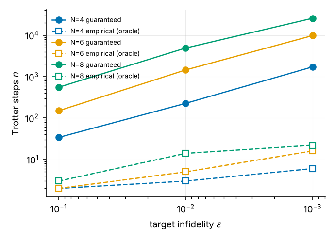

Guaranteed (solid) and empirical (open markers) Trotter step counts versus target infidelity.

| $N$ | $\varepsilon$ | $n_{\mathrm{guar}}$ | $n_{\mathrm{emp}}$ | ratio | bound $1-F$ | measured $1-F$ at $n_{\mathrm{guar}}$ | sharpened bound | $n_{\mathrm{guar}}^{\mathrm{sharp}}$ | CX guar. | CX emp. |
| --- | --- | --- | --- | --- | --- | --- | --- | --- | --- | --- |
| 4 | $10^{-1}$ | 34 | 2 | 17 | 0.0999 | 3.2e-3 | 0.035 | 14 | 723 | 51 |
| 4 | $10^{-2}$ | 226 | 3 | 75 | 0.0100 | 2.7e-4 | 3.2e-3 | 100 | 4 755 | 72 |
| 4 | $10^{-3}$ | 1 719 | 6 | 287 | 0.0010 | 3.1e-5 | 3.2e-4 | 760 | 36 108 | 135 |
| 6 | $10^{-1}$ | 150 | 2 | 75 | 0.0996 | 6.6e-3 | 0.034 | 60 | 5 265 | 85 |
| 6 | $10^{-2}$ | 1 450 | 5 | 290 | 0.0100 | 7.6e-4 | 3.5e-3 | 589 | 50 765 | 190 |
| 6 | $10^{-3}$ | 9 797 | 16 | 612 | 0.0010 | 2.8e-5 | 3.2e-4 | 4 328 | 342 910 | 575 |
| 8 | $10^{-1}$ | 555 | 3 | 185 | 0.0962 | 1.2e-2 | 0.038 | 175 | 27 216 | 168 |
| 8 | $10^{-2}$ | 4 903 | 14 | 350 | 0.0100 | 1.6e-4 | 3.2e-3 | 2 164 | 240 268 | 707 |
| 8 | $10^{-3}$ | 25 634 | 22 | 1 165 | 0.0010 | (not simulated) | – | 11 317 | 1 256 087 | 1 099 |

($J_2=0$, $L=1$, floor design. $n_{\mathrm{guar}}^{\mathrm{sharp}}$ is the a-priori step number if the sharpened composition of §3 replaced R4, computed on the un-gridded design, i.e. indicative.)

Three observations.

*(a) The guarantee is sound but loose.* No design violated its bound. The measured infidelity at $n_{\mathrm{guar}}$ is 8–63× below the bound, and the sharpened composition (valid in every case) tightens the bound by 2.5–3.1× and reduces the a-priori $n$ by 2.3–3.2×. Two further sources of slack remain: the commutator norm is a worst case over the full Hilbert space (the pulse-level operator error is already only $\le 0.24$ of the bound, §5.1) and the state error on low-energy states is far smaller than the operator error (measured state error $2\times10^{-4}$ vs. bound $5.6\times10^{-2}$ at $N=6$, $\varepsilon=10^{-2}$).

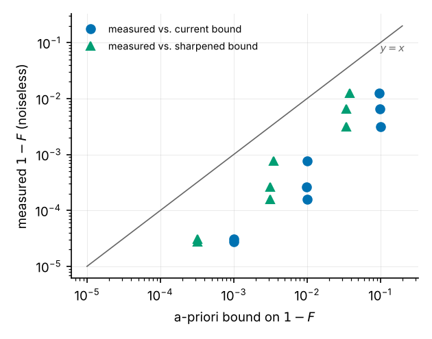

Measured infidelity vs. a-priori bound. All points lie below $y=x$.

*(b) The “empirical” point is an oracle and sometimes not a filter at all.* $n_{\mathrm{emp}}$ is defined by comparison with the exact ground state. In several rows (e.g. $N=6$, $\varepsilon=10^{-1},10^{-2}$; $N=8$, $\varepsilon=10^{-1}$) the certified $\eta$ at $n_{\mathrm{emp}}$ is $\approx1$: the snapped Trotter step ($dt\approx3.6$ in scaled units, i.e. $W\,dt\approx13$ rad) is so coarse that the circuit is no longer an approximation of the designed filter, and the measured improvement is a property of that particular discretisation, not something a bound can certify or a user could know a priori. The empirical numbers should be presented as a lower envelope, not as the algorithm’s cost.

*(c) Cost.* The guaranteed circuits for $N=6$ at $\varepsilon=10^{-2}$ have 1450 Trotter steps, 50 765 CX, depth $\approx2\times10^{5}$ and $\approx7\times10^{4}$ non-Clifford rotations, i.e. $\sim1.4\times10^{6}$ T gates under the code’s own synthesis estimate, with success probability $P_{\mathrm{succ}}\approx0.72$.

### 5.3 Is the filter worth it? Baselines

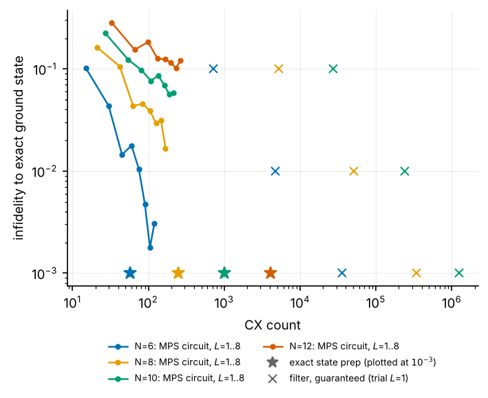

CX versus infidelity for the DMRG-derived MPS circuit ($L=1..8$), exact state preparation (stars, plotted at a nominal $10^{-3}$) and the guaranteed filter (crosses).

Exact preparation of the ED ground state with qiskit’s generic isometry synthesis costs 57, 247, 1013 and 4083 CX for $N=6,8,10,12$ ($\approx2^{N}$). The guaranteed filter at $\varepsilon=10^{-2}$ costs 50 765, 240 268 and 696 807 CX for $N=6,8,10$, i.e. **890×, 970× and 690×** more than exact preparation, and 2–3 orders of magnitude more than the entire $L\le8$ MPS-circuit family (15–264 CX). The MPS-circuit baseline is itself imperfect and *non-monotone in $L$* (e.g. $N=6$: infidelity $1.4\times10^{-2}$ at $L=3$, $1.8\times10^{-2}$ at $L=4$; the compilation is a local optimisation), and at $N=10,12$ it has not converged by $L=8$ (5.8 % and 12 % infidelity). Extrapolating the fitted $N^5$ filter cost against the $2^N$ exact cost suggests a crossover near $N\approx26$ — but dense isometry synthesis is not available at that size and the extrapolation ignores the decay of $\gamma$ with $N$; the relevant comparators there are MPS-based sequential preparation [7] and QETU/Lin–Tong filters [5,6]. The full equal-fidelity comparison with the `mps-to-circuit` approximate and sequential circuits, for $N=6$–$12$ and $J_2\in\{0,0.4\}$, is given in §5.8.

### 5.4 Scaling with system size

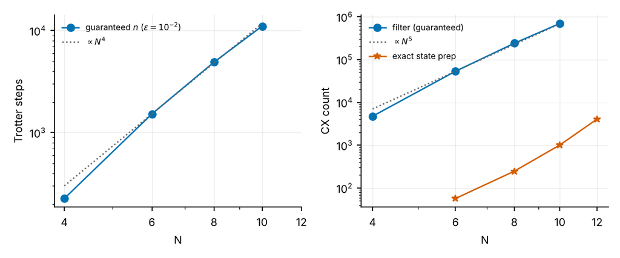

Left: guaranteed Trotter steps at $\varepsilon=10^{-2}$ versus $N$. Right: guaranteed CX versus $N$, compared with exact state preparation.

Guaranteed $n$ for $N=4,6,8,10$: 226, 1523, 4903, 11 060 (fit exponent 4.3 over 4–10, 3.9 over 6–10); CX: $4.8\times10^3$, $5.3\times10^4$, $2.4\times10^5$, $7.0\times10^5$ (exponent 5.0–5.5). This agrees with the structure of the bound, $n\propto\alpha_{\mathrm{phys}}T_{\mathrm{phys}}^{2}/(\sqrt{p_g}\,d_T)$ with $\alpha_{\mathrm{phys}}\propto N$ (3.0, 4.5, 6.0 for $N=6,8,10$ at $J_2=0$), $T_{\mathrm{phys}}\propto1/\Delta_{\mathrm{gap}}\propto N$ (gap 0.49, 0.39, 0.33) giving $N^3$, with the remaining power from $\gamma(N)$ falling at fixed $L$ (0.90, 0.84, 0.78) and hence tighter $\eta_*$, plus the per-step CX growing $\propto N$. (Note that rescaling by $W$ cancels: $\alpha T^2$ is $W$-independent.) Using $L=3$ trial layers raises $\gamma$ (0.98, 0.94, 0.90 for $N=6,8,10$) and lowers guaranteed CX by 3.2×, 1.7× and 1.5× respectively: the benefit of a better trial state shrinks with $N$ because the evolution time $T\propto1/\Delta_{\mathrm{gap}}$ is set by the gap, not by $\gamma$.

### 5.5 The DMRG-derived inputs

| $N$ | $\|\Delta E_0\|$ | $\Delta E_1=E_1^{\mathrm{DMRG}}-E_1$ | rel. gap error | $\|\Delta E_{\mathrm{top}}\|$ | $\mathrm{Var}(H)$ | $\|\langle\psi_{\mathrm{DMRG}}\|E_0\rangle\|^2$ |
| --- | --- | --- | --- | --- | --- | --- |
| 6 | 3e-15 | −4e-16 | −7e-15 | 3e-15 | ≈0 | 1.0 |
| 8 | 2e-15 | 2e-15 | 1e-15 | 5e-15 | ≈0 | 1.0 |
| 10 | 5e-10 | 3.5e-10 | −3.7e-10 | 3e-13 | 2.5e-9 | 1.0 |
| 12 | 1.2e-9 | 9.3e-10 | −8.5e-10 | 4e-12 | 5.8e-9 | 1.0 |
| 14 | 1.8e-9 | 1.3e-9 | −2.0e-9 | 7e-12 | 8.3e-9 | 1.0 |
| 16 | 2.2e-9 | 2.4e-9 | 7e-10 | 1e-11 | 1.0e-8 | 1.0 |

($J_2=0$. Rows with ≈0 variance are at rounding level. $J_2=0.2411$ ($N=6$–$16$) and $J_2=0.5$ ($N=6$–$10$) show the same behaviour: $|\Delta E_0|,|\Delta E_1|\le2.6\times10^{-9}$, overlap 1; the full table is in `results/exp3a_*.json`, which is written when the sweep finishes.) DMRG reproduces $E_0$, $E_1$ and $E_{\mathrm{top}}$ to $\lesssim2\times10^{-9}$ and the ground state to overlap 1 against sparse-Lanczos ED up to $N=16$. Three caveats are relevant to certification, not to accuracy:

1. $\Delta E_1\ge0$ (up to rounding), as expected for a variational excited-state energy — the **unsafe direction** for a gap used as a *lower* bound. The size is negligible here, but nothing guarantees it for large $N$ or frustrated $J_2$.
2. The relative gap error changes sign, so the sign of the error is not controlled either.
3. The code’s $e_0=\sqrt{\mathrm{Var}H}/W$ (e.g. $10^{-4}/W$ at $N=16$) is five orders of magnitude larger than the true energy error ($2\times10^{-9}$): it is simultaneously non-rigorous (an eigenvalue within $\sqrt{\mathrm{Var}}$ need not be the lowest) and wasteful (it enters $|F(E_0)|\ge|F(0)|-Le_0$). A Temple-type lower bound $E_0\ge\langle H\rangle-\mathrm{Var}/(\tilde E_1-\langle H\rangle)$, which is *quadratically* smaller, becomes available as soon as a rigorous lower bound $\tilde E_1$ on the first excitation is accepted — the same quantity the certificate already needs.

(The DMRG penalty state $\psi_1$ has weight 0.03–0.56 on any *single* ED vector at $E_1$ because $E_1$ is a threefold-degenerate triplet; this is not an error.)

### 5.6 Over-estimating the gap, and what symmetry could buy

We designed filters for a gap over-estimated by $s\in\{-20\%,\dots,+100\%\}$ ($N=6$, $J_2=0$, $\varepsilon_\ell=10^{-3}$) and evaluated them on the true spectrum.

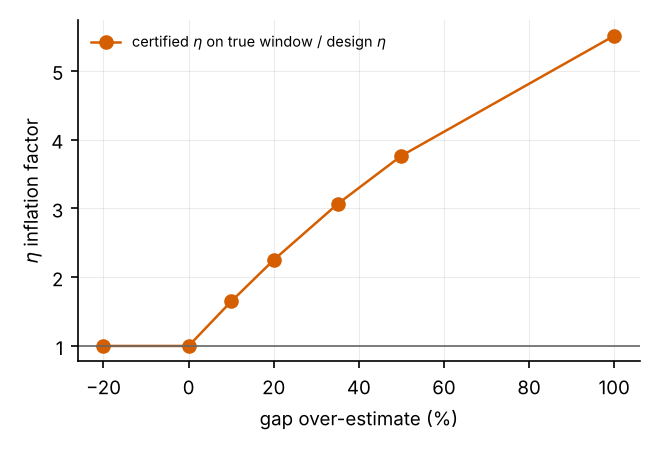

Inflation of the certified $\eta$ when the design gap exceeds the true gap.

The certificate fails as soon as the design gap exceeds the true one: certified $\eta$ on the true window rises from 0.092 to 0.15, 0.21, 0.28, 0.34 and 0.50 for $s=10,20,35,50,100\%$ (design target 0.092). The *measured* leakage of this particular trial state nevertheless stays below the $10^{-3}$ target ($\le7\times10^{-4}$). The reason is symmetry: the $L=1$ trial state has 96.3 % of its weight in $S=0$, 0.49 % in $S=1$, 3.2 % in $S=2$, and the triplet that fixes the gap carries almost none of it, while the first $S=0$ excitation lies at 2.66× the triplet gap ($N=6$, $J_2=0$). A rigorous statement therefore needs the sector weights, which suggests a concrete improvement (§6): because every bond exponential is SU(2)-symmetric (“bond” ordering) the Trotterised evolution preserves $S$, so one may certify with sector-dependent windows. The potential saving, since $n\propto\Delta^{-2}$, is $(\Delta_{\mathrm{sector}}/\Delta_{\mathrm{any}})^2$:

| $J_2$ | $N=6$ | $N=8$ | $N=10$ |
| --- | --- | --- | --- |
| 0 | 7.1× | 7.0× | 6.9× |
| 0.2411 | 4.2× | 4.1× | 4.1× |
| 0.5 | 1.8× | 1.6× | 1.4× |

(ratio $(\Delta_{\mathrm{sector}}/\Delta_{\mathrm{any}})^2$ from exact diagonalisation; $N=12$, $J_2=0$: 6.8×.)

### 5.7 The $J_2=0.5$ case is trivial, and exposes a defect

At the Majumdar–Ghosh point the open even chain has the product-of-dimers ground state [8], which a single brickwork layer reproduces exactly: we find $\gamma=1$ (to double precision) for $N=4$–$12$. `floor_vs_precision` then correctly returns “no filter needed” rows ($m=0$), but `choose_floor_design` counts them as infeasible and `make_design` silently falls back to the legacy `builder` design with a hard-coded $P_{\mathrm{succ}}\ge0.9$. The pipeline then reports guaranteed circuits of 24 261, 511 068 and 1 157 409 CX for $N=4,8,10$ to prepare a state it already has, and the oracle-empirical search “meets” $\varepsilon=0.1$ with a state that has *lost* 9 % fidelity. The near-MG regime is therefore a poor benchmark for the algorithm; the interesting frustrated regime is $J_2\sim0.3$–$0.45$ or non-dimerised trial limits (small $L$ at larger $N$).

### 5.8 Baselines at equal fidelity: the filter does not beat MPS preparation here

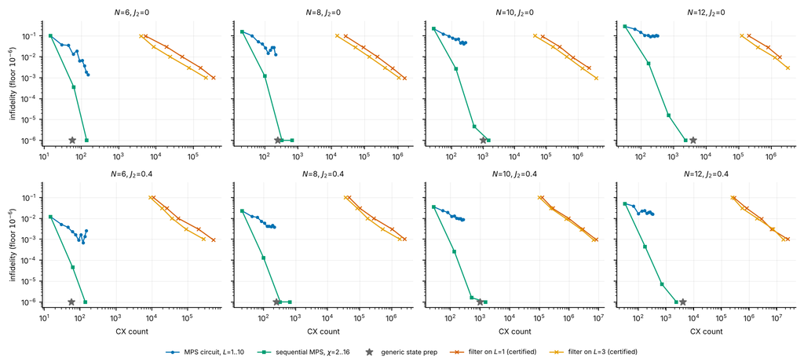

CX versus infidelity for the DMRG-derived MPS circuit ($L=1..10$, `mps-to-circuit` *approximate*), the sequential (*exact*) MPS circuit at bond dimension $\chi=2,4,8,16$, generic isometry state preparation, and the certified filter on $L=1$ and $L=3$ trial circuits. Filter points are certified bounds. Infidelity floor $10^{-6}$.

Table 5.8 lists, for each target $\varepsilon$, the cheapest baseline that reaches it (measured against the exact ground state) next to the filter’s cost (including the trial circuit): the *certified* design of §3 and the *hybrid protocol* of §5.10.

| $N$ | $J_2$ | $\varepsilon$ | best baseline (CX) | filter: certified (CX) | filter: hybrid protocol (CX) | certified / baseline | hybrid / baseline |
| --- | --- | --- | --- | --- | --- | --- | --- |
| 6 | 0 | 0.1 | MPS circuit (30) | 4,000 | 155 | 133× | 5.2× |
| 6 | 0 | 0.01 | generic prep (57) | 23,880 | 295 | 419× | 5.2× |
| 6 | 0 | 0.001 | generic prep (57) | 215,260 | 715 | 3776× | 13× |
| 8 | 0 | 0.1 | MPS circuit (63) | 14,861 | 315 | 236× | 5.0× |
| 8 | 0 | 0.01 | sequential MPS (100) | 137,998 | 1,001 | 1380× | 10× |
| 8 | 0 | 0.001 | generic prep (247) | 1,066,499 | 2,765 | 4318× | 11× |
| 10 | 0 | 0.1 | MPS circuit (81) | 43,551 | 783 | 538× | 9.7× |
| 10 | 0 | 0.01 | sequential MPS (137) | 447,822 | 1,791 | 3269× | 13× |
| 10 | 0 | 0.001 | sequential MPS (519) | 3,802,824 | 3,051 | 7327× | 5.9× |
| 12 | 0 | 0.1 | sequential MPS (174) | 125,532 | 1,573 | 721× | 9.0× |
| 12 | 0 | 0.01 | sequential MPS (174) | 1,292,390 | 2,497 | 7428× | 14× |
| 12 | 0 | 0.001 | sequential MPS (709) | – | 7,425 | – | 10× |
| 6 | 0.4 | 0.1 | MPS circuit (15) | 9,117 | 330 | 608× | 22× |
| 6 | 0.4 | 0.01 | MPS circuit (30) | 37,215 | 645 | 1240× | 22× |
| 6 | 0.4 | 0.001 | generic prep (57) | 285,372 | 1,779 | 5007× | 31× |
| 8 | 0.4 | 0.1 | MPS circuit (21) | 36,554 | 567 | 1741× | 27× |
| 8 | 0.4 | 0.01 | MPS circuit (84) | 178,878 | 1,841 | 2130× | 22× |
| 8 | 0.4 | 0.001 | sequential MPS (99) | 1,828,526 | 7,301 | 18470× | 74× |
| 10 | 0.4 | 0.1 | MPS circuit (27) | 100,755 | 1,455 | 3732× | 54× |
| 10 | 0.4 | 0.01 | sequential MPS (136) | 823,204 | 3,359 | 6053× | 25× |
| 10 | 0.4 | 0.001 | sequential MPS (136) | 6,707,397 | 11,451 | 49319× | 84× |
| 12 | 0.4 | 0.1 | MPS circuit (33) | 249,852 | 1,797 | 7571× | 54× |
| 12 | 0.4 | 0.01 | sequential MPS (174) | 1,943,145 | 5,913 | 11168× | 34× |
| 12 | 0.4 | 0.001 | sequential MPS (174) | 17,365,356 | 37,665 | 99801× | 216× |

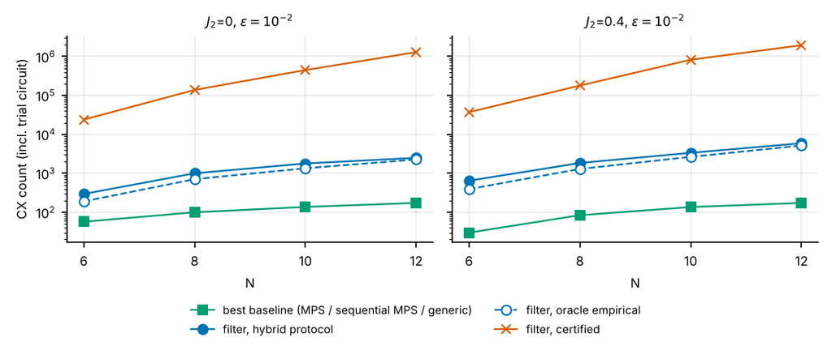

CX at $\varepsilon=10^{-2}$ versus $N$: best baseline, certified filter, hybrid protocol and oracle-empirical filter.

### 5.9 Where the certified-versus-empirical gap comes from

The worst-case constant $\alpha=\sum_g\|[H_g,\sum_{g'>g}H_{g'}]\|$ is an operator norm over the whole Hilbert space. The first-order Lie–Trotter error vector acting on a state $\psi$ is $\tfrac{t^2}{2k}C\psi$ with $C=\sum_{g<g'}[H_{g'},H_g]$ (anti-Hermitian), so what a low-energy state actually feels is $\|C\psi\|$, not $\alpha$:

| $N$ | $J_2$ | $\alpha$ (worst case) | $\\|C\psi_0\\|$ (ground state) | $\alpha/\\|C\psi_0\\|$ | $\alpha/\\|C\psi_{E_1}\\|$ |
| --- | --- | --- | --- | --- | --- |
| 4 | 0 | 0.2679 | 0.0000 | (=0) | 2.3 |
| 6 | 0 | 0.2141 | 0.0075 | 28.5 | 4.8 |
| 8 | 0 | 0.1713 | 0.0050 | 34.1 | 7.9 |
| 10 | 0 | 0.1417 | 0.0034 | 41.2 | 11.6 |
| 4 | 0.4 | 0.4177 | 0.0574 | 7.3 | 3.5 |
| 6 | 0.4 | 0.3480 | 0.0369 | 9.4 | 6.4 |
| 8 | 0.4 | 0.2832 | 0.0251 | 11.3 | 9.0 |
| 10 | 0.4 | 0.2361 | 0.0184 | 12.8 | 11.2 |

### 5.10 A hybrid, non-oracle protocol: rigorous leakage plus empirical Trotter control

The “empirical” step counts of §5.2 use the exact ground state and are not available to a user. We therefore replace them by a protocol that uses only quantities a practitioner can obtain:

1. **Leakage — rigorous.** For the snapped step grid, certify $\eta$ (R1) and compute the leakage bound $\ell(n)$ from R2 (needs $\gamma$ and $\Delta$).
2. **Trotter — empirical, Richardson-type.** Run the same circuit family at $n$ and $2n$ and compute $\delta_n=1-|\langle\psi_n|\psi_{2n}\rangle|^2$; because the error vector scales as $1/n$, the distance to the $n\to\infty$ state is $\approx2\sqrt{\delta_n}$.
3. **Accept** the smallest $n$ on a geometric grid with $(\sqrt{\ell(n)}+2\sqrt{\delta_n})^2\le\varepsilon$ and certified $\eta<1$.

The exact ground state is used only afterwards, to validate. (On hardware the two-run comparison is replaced by the convergence of an energy or other observable estimated at $n$ and $2n$.) Results ($L=1$ trial, $J_1=1$; rows for $N=10$ ($\varepsilon=10^{-3}$) and $N=12$ ($J_2=0$) were rerun with the full floor-search settings (6 leakage fractions, $m\in\{4,6,8\}$), which found a feasible `floor` design in every case, so no row uses the legacy `builder` fallback; † would mark such a row. The floor search is a heuristic local optimiser, so costs for the same target can differ by tens of percent between search settings (e.g. certified CX at $N=12$, $\varepsilon=10^{-2}$: 1.29M with the reduced search of §5.8 versus 1.67M here)):

| $N$ | $J_2$ | $\varepsilon$ | $n$ (protocol) | CX | measured $1-F$ | $P_{\rm succ}$ | oracle $n$ / CX | certified $n$ / CX | certified ÷ protocol (CX) |
| --- | --- | --- | --- | --- | --- | --- | --- | --- | --- |
| 6 | 0 | 0.1 | 4 | 155 | 0.015 | 0.58 | 2 / 85 | 150 / 5,265 | 34× |
| 6 | 0 | 0.01 | 8 | 295 | 0.00099 | 0.6 | 5 / 190 | 1523 / 53,320 | 181× |
| 6 | 0 | 0.001 | 20 | 715 | 0.00036 | 0.55 | 16 / 575 | 10286 / 360,025 | 504× |
| 8 | 0 | 0.1 | 6 | 315 | 0.023 | 0.53 | 3 / 168 | 555 / 27,216 | 86× |
| 8 | 0 | 0.01 | 20 | 1,001 | 0.00092 | 0.54 | 14 / 707 | 4903 / 240,268 | 240× |
| 8 | 0 | 0.001 | 56 | 2,765 | 0.00022 | 0.54 | 25 / 1,246 | 32653 / 1,600,018 | 579× |
| 10 | 0 | 0.1 | 12 | 783 | 0.0064 | 0.44 | 7 / 468 | 1212 / 76,383 | 98× |
| 10 | 0 | 0.01 | 28 | 1,791 | 0.0013 | 0.51 | 21 / 1,350 | 11060 / 696,807 | 389× |
| 10 | 0 | 0.001 | 48 | 3,051 | 0.0004 | 0.45 | 36 / 2,295 | 61683 / 3,886,056 | 1274× |
| 12 | 0 | 0.1 | 20 | 1,573 | 0.0071 | 0.55 | 7 / 572 | 2673 / 205,854 | 131× |
| 12 | 0 | 0.01 | 32 | 2,497 | 0.0015 | 0.48 | 29 / 2,266 | 21651 / 1,667,160 | 668× |
| 12 | 0 | 0.001 | 96 | 7,425 | 0.00019 | 0.52 | 44 / 3,421 | 119858 / 9,229,099 | 1243× |
| 6 | 0.4 | 0.1 | 5 | 330 | 0.014 | 0.91 | 3 / 204 | 177 / 11,166 | 34× |
| 6 | 0.4 | 0.01 | 10 | 645 | 0.0028 | 0.55 | 6 / 393 | 882 / 55,581 | 86× |
| 6 | 0.4 | 0.001 | 28 | 1,779 | 0.00053 | 0.49 | 22 / 1,401 | 8323 / 524,364 | 295× |
| 8 | 0.4 | 0.1 | 6 | 567 | 0.015 | 0.88 | 4 / 385 | 518 / 47,159 | 83× |
| 8 | 0.4 | 0.01 | 20 | 1,841 | 0.0046 | 0.53 | 14 / 1,295 | 3128 / 284,669 | 155× |
| 8 | 0.4 | 0.001 | 80 | 7,301 | 0.00043 | 0.8 | 54 / 4,935 | 28715 / 2,613,086 | 358× |
| 10 | 0.4 | 0.1 | 12 | 1,455 | 0.0076 | 0.79 | 5 / 622 | 1051 / 125,096 | 86× |
| 10 | 0.4 | 0.01 | 28 | 3,359 | 0.006 | 0.66 | 22 / 2,645 | 8251 / 981,896 | 292× |
| 10 | 0.4 | 0.001 | 96 | 11,451 | 0.00054 | 0.8 | 73 / 8,714 | 70053 / 8,336,334 | 728× |
| 12 | 0.4 | 0.1 | 12 | 1,797 | 0.023 | 0.67 | 9 / 1,356 | 1979 / 290,946 | 162× |
| 12 | 0.4 | 0.01 | 40 | 5,913 | 0.0064 | 0.53 | 35 / 5,178 | 18004 / 2,646,621 | 448× |
| 12 | 0.4 | 0.001 | 256 | 37,665 | 0.00035 | 0.82 | 122 / 17,967 | 175985 / 25,869,828 | 687× |

## 6. Code audit and recommended changes

Severity: **H** invalidates a claim or can silently produce a wrong/ruinous result; **M** weakens a claim or wastes resources; **L** hygiene. Line references are to `AARON/j1j2_filter`.

[output not shown]

**Status after this evaluation.** Items 1, 3 and 4 are fixed in the repository (explicit no-filter design when $1-\gamma<10^{-9}$, handled by `runner`, `export_circuits` and `study.py`; `ORDER\neq1` raises; dense spectrum check only for $N\le12$, `eigsh` otherwise). Item 5 is partly addressed: `study.py` is present and its imports now point at the refactored `core/` modules instead of the stale `builder.py`; its defaults now use *guaranteed* designs, $J_2\in\{0,0.2411,0.4\}$ and $N\le12$. Items 2, 6–13 remain open.

### 6.1 Methodological improvements

1. **Sharpened composition** (item 10): a free, proven 2.5–3.1× tighter bound and 2.3–3.2× fewer guaranteed steps.
2. **Symmetry-resolved certification**: let $w_s$ be the trial weight in sector $s$ and $\Delta_s$ the gap of that sector. Then $\ell\le\sum_sw_s\,(\sup_{[\Delta_s,1]}|F|)^2/F(0)^2$ over the ground-state sector and the (small) remainder bounded with the global gap. Because bond-ordered Trotter steps are exactly SU(2)-symmetric, the sector weights are conserved by the (Trotterised) evolution, so this is rigorous given the sector weights, which are cheap to compute from the trial MPS. Potential saving up to $(\Delta_s/\Delta)^2\approx7\times$ in $n$ at $J_2=0$ (§5.6).
3. **Subspace-restricted Trotter bounds**: replace the global $\alpha$ by commutator norms restricted to the low-energy subspace populated by the trial state (the observed state error is ≈ 300× below the bound), or use higher-order formulas with the matching commutator bound.
4. **Tensor-network simulation of the filter.** The DMRG advantage is lost as long as every number comes from dense vectors; the controlled evolution $e^{-itH\otimes Z}$ is an MPO-friendly operation, so MPS/TEBD simulation of the Trotterised filter would allow $N\sim30$–$100$ and show the real DMRG→circuit→filter story.

## 7. Conclusions and framing

**Established.** (a) The mathematics of the filter, leakage, Trotter and composition bounds is correct and held in every test; a sharpened composition is proved and verified. (b) The certified guarantee is loose by a factor $\sim10^{2}$–$10^{3}$ because the commutator constant is a worst case over the whole Hilbert space; the slack is quantified (§5.9) and grows with $N$. (c) A hybrid protocol — rigorous leakage plus a Richardson-type Trotter estimate, with no oracle — met its target in every completed case at 30–1300× lower CX than the certified circuits. (d) DMRG supplies $E_0$, $E_1$, $E_{\rm top}$ and the ground state to $\sim10^{-9}$ up to $N=16$, but cannot certify the gap or $\gamma$.

**Negative result.** For the open $J_1$–$J_2$ chain at $N\le12$ and $J_2\in\{0,0.4\}$ the filter does not beat classical-then-quantum MPS preparation: the best baseline is cheaper than the certified filter by $10^{2}$–$10^{5}\times$ and than the hybrid protocol by 5–216× (median ≈22×), because a bond dimension of 4–8 already prepares these states to $\lesssim10^{-2}$–$10^{-5}$ with a few hundred CX. The filter’s cost is set by the physical gap ($T\propto1/\Delta$) and Trotter error, not by how entangled the state is, so its relative merit can only improve for states whose MPS preparation cost grows quickly — which none of the tested ones do.

**Framing.** We therefore recommend presenting this work as (i) a *methodology* for certified SBC filtering (rigorous bounds, sharpened composition, symmetry-resolved certification, and the hybrid protocol), (ii) a *verification harness* with open code, and (iii) an *honest comparison* showing that for 1D chains of this size MPS preparation suffices, with the regimes where the filter might help named explicitly. It should not claim a resource advantage.

**What would turn the negative result into a positive one (open work).**

1. *States that are expensive for MPS circuits:* two-dimensional or ladder lattices, critical systems at larger $N$ where $\chi$ must grow, or trial states from methods other than DMRG. These require tensor-network or other large-$N$ simulation of the filter itself; dense vectors stop at $N\approx14$.
2. *Tighter and cheaper filtering:* subspace-restricted Trotter bounds (the observed constant is 10–40× below $\alpha$), second-order formulas with the matching commutator bound, symmetry-resolved windows (up to $\approx7\times$ in $n$ at $J_2=0$), absorbing the energy shift into the phases, and Hamiltonian-aware compilation of the controlled bond exponentials.
3. *Rigor for large $N$:* a certified lower bound on the gap (e.g. symmetry-resolved DMRG plus a Temple/Weinstein-type bound) so that $\Delta$, $\gamma$ and $e_0$ are not assumptions.
4. *Competing quantum methods* under the same trial state: QETU/Lin–Tong filtering and the rodeo algorithm with random times.
5. *Completeness of the present data:* the hybrid protocol for $L=3$ trial circuits and for $N>12$ (needs a non-dense simulation); a deterministic, globally better floor-design search (the present one is a multistart local optimiser); second-order Trotter; a fault-tolerant resource model with early-abort statistics; and verified references and T-count constants.

## 8. Reproducibility

Code: `AARON/evaluation/experiments` (`exp1_primitives.py` building-block tests; `exp2_end_to_end.py N J2 L`; `exp3_dmrg_inputs.py`; `exp3b_baseline.py`; `exp4_gap_and_symmetry.py`; `exp5_scaling.py`; `make_figures.py`). Raw outputs: `AARON/evaluation/results/*.json`; logs: `AARON/evaluation/logs`. All experiments call `AARON/j1j2_filter` unmodified. Environment: Python 3.12, numpy 2.x, scipy 1.18, qiskit 2.5.2, quimb 1.15, `mps-to-circuit`; run with `OMP_NUM_THREADS=1` (multi-threaded BLAS made the SLSQP filter design several times slower). Floor-design settings for the scaling study were reduced for speed (`FLOOR_EPS_FRACS=[0.2,0.1,0.05]`, `FLOOR_M=[4,6]`); end-to-end runs used the defaults.

**Limitations of this evaluation.** Single trial-circuit compilation per $(N,J_2,L)$ (the compiler is a local optimiser, so $\gamma$ is not unique); the §5.2 end-to-end simulations cover $J_2=0$ only (plus the trivial $J_2=0.5$); $J_2=0.4$ enters through the baseline (§5.8), looseness (§5.9) and hybrid-protocol (§5.10) experiments; the $N=8$, $\varepsilon=10^{-3}$ guaranteed design was not simulated (beyond the simulation cap); the scaling fits use four sizes; the crossover estimate is an extrapolation. References were written from memory and must be checked before submission.

## References

1. I. Stetcu, A. Baroni, J. Carlson, *Projection algorithm for state preparation on quantum computers*, Phys. Rev. C **105**, 064308 (2022).
2. K. Choi, D. Lee, J. Bonitati, Z. Qian, J. Watkins, *Rodeo algorithm for quantum computing*, Phys. Rev. Lett. **127**, 040505 (2021).
3. Z. Qian et al., *Demonstration of the rodeo algorithm on a quantum computer*, arXiv:2110.07747.
4. A. M. Childs, Y. Su, M. C. Tran, N. Wiebe, S. Zhu, *Theory of Trotter error with commutator scaling*, Phys. Rev. X **11**, 011020 (2021).
5. L. Lin, Y. Tong, *Near-optimal ground state preparation*, Quantum **4**, 372 (2020).
6. Y. Dong, L. Lin, Y. Tong, *Ground-state preparation and energy estimation on early fault-tolerant quantum computers via quantum eigenvalue transformation of unitary matrices*, PRX Quantum **3**, 040305 (2022).
7. C. Schön, E. Solano, F. Verstraete, J. I. Cirac, M. M. Wolf, *Sequential generation of entangled multiqubit states*, Phys. Rev. Lett. **95**, 110503 (2005).
8. C. K. Majumdar, D. K. Ghosh, *On next-nearest-neighbor interaction in linear chain*, J. Math. Phys. **10**, 1388 (1969).
9. S. R. White, *Density matrix formulation for quantum renormalization groups*, Phys. Rev. Lett. **69**, 2863 (1992); U. Schollwöck, Ann. Phys. **326**, 96 (2011).
10. K. Okamoto, K. Nomura, Phys. Lett. A **169**, 433 (1992).